# Lab 05 — Sampling and Bootstrap Distributions

EAES 480 — Modern Statistics in Earth & Environmental Science

March 04, 2026

# Overview

In EAES we almost never observe an entire population. Instead, we take **samples** and compute **point estimates** (like a mean) to infer **population parameters**.

This lab focuses on four core ideas:

1. **Relative error** of point estimates (accuracy)
2. **Standard error (SE)** and how it changes with sample size
3. How **replication** (many repeated samples) creates an approximate **sampling distribution**
4. (Intro) **Bootstrap** distributions: resampling from one sample to approximate uncertainty

## Coding expectations (Week 7+)

This lab uses a mix of: - **Fill-in-the-blank** (quick checks) - **Partial pipelines** (you finish the analysis) - **From-scratch chunks** (you write the full solution)

Use slides + past labs + Discord as needed, but make sure your final code is **your own** and runs **top-to-bottom**.

# Data

## Load data (partial pipeline)

Complete the pipeline so `df` is a clean tibble. Filter for 2023, and replace fill values (-9999) with na.

```r
# GOAL: Read the CSV from the repo and clean column names.
# TODO: finish this pipeline.

df <- read_csv("data/us-ams-simple.csv", na = c("-9999")) %>%
  clean_names() %>%
  filter(year_local == 2023)



glimpse(df)
```

```
## Rows: 16,973
## Columns: 10
## $ year_local <dbl> 2023, 2023, 2023, 2023, 2023, 2023, 2023, 2023, 2023, 2023,…
## $ doy        <dbl> 1.0000, 1.0208, 1.0416, 1.0624, 1.0833, 1.1041, 1.1249, 1.1…
## $ daytime    <dbl> 0, 0, 0, 0, 0, 0, 0, 0, NA, NA, 0, 0, 0, 0, 0, 0, 1, 1, 1, …
## $ fc         <dbl> 1.4444700, 1.0018700, 1.7665700, 0.4639850, 0.8243290, 0.64…
## $ le         <dbl> -2.975490, -1.814240, -5.101540, -4.854642, -2.419090, -10.…
## $ ta         <dbl> 7.433350, 7.783740, 8.273390, 8.702240, 8.896600, 8.567610,…
## $ reco       <dbl> 1.291612, 1.312279, 1.341193, 1.366625, 1.378268, 1.359013,…
## $ gpp        <dbl> -0.1528577, 0.3104090, -0.4253767, 0.9026402, 0.5539394, 0.…
## $ swc        <dbl> 36.13111, 36.11948, 36.11560, 36.11172, 36.11172, 36.10008,…
## $ ts         <dbl> 2.50, 2.50, 2.50, 2.50, 2.50, 2.50, 2.50, 2.50, 2.50, 2.50,…
```

## Derive time columns

Write code to add: - `date` from `year_local` + `doy` - `month` as labeled abbreviated month (Jan–Dec) - `day_night` as “Day”/“Night” from `daytime` (0/1)

```r
# GOAL: Create date/month/day_night columns.
# HINT: DOY is 1-indexed, so use (doy - 1) with origin "YYYY-01-01".

df <- df %>%
 mutate(
    # TODO: create a Date column from year_local and doy
    # HINT: Jan 1 is DOY = 1, so use (doy - 1) with origin = "YYYY-01-01"
    date = as.Date(doy - 1, origin = paste0(year_local, "-01-01")),

    # TODO: create a month column (numeric 1–12 or labeled months)
    month = month(date, label = TRUE, abbr = TRUE),

    # TODO: make a day/night label using daytime (0/1)
    day_night = if_else(daytime == 1, "Day", "Night")
  )

df %>% count(month)
```

| month | n |
| --- | --- |
| Jan | 1488 |
| Feb | 1344 |
| Mar | 1486 |
| Apr | 1440 |
| May | 1488 |
| Jun | 1440 |
| Jul | 1488 |
| Aug | 1452 |
| Sep | 1440 |
| Oct | 1488 |

[output cut: 3 more lines]

```r
df %>% count(day_night)
```

| day_night | n |
| --- | --- |
| Day | 8287 |
| Night | 7767 |
| NA | 919 |

# Population parameters vs point estimates

## 1) Choose variables (fill-in)

Pick **2–3 variables** to analyze. Include at least **one flux** variable (e.g., `nee`, `fc`, `gpp`) and optionally one meteorological variable (e.g., `ta`, `le`).

```r
vars <- c(
  "gpp",  # e.g., "fc"
  "ta"  # e.g., "ta"
)

# CHECK: confirm these columns exist (should return character(0))
setdiff(vars, names(df))
```

```
## character(0)
```

## 2) Compute population parameters (partial pipeline)

Complete the code to compute **population mean** and **population SD** for each selected variable.

Your output should be a tibble named `pop` with columns: `var`, `mean`, `sd`.

```r
# GOAL: Create a tidy table of population parameters for vars.
# TODO: complete this pipeline.

pop <- df %>%
  summarise(across(
    all_of(vars),
    list(
      mean = ~mean(.x, na.rm = TRUE),
      sd   = ~sd(.x, na.rm = TRUE)
    ),
    .names = "{.col}__{.fn}"
  )) %>%
  pivot_longer(
    everything(),
    names_to = c("var", "stat"),
    names_sep = "__",
    values_to = "value"
  ) %>%
  pivot_wider(names_from = stat, values_from = value)       # TODO: pivot_wider

pop
```

| var | mean | sd |
| --- | --- | --- |
| gpp | 6.045922 | 10.35808 |
| ta | 13.415388 | 10.27403 |

**Prompt (2–3 sentences):** Which variable has the largest population SD? What does that imply about the variability of that process?

> *The GPP has the largest population SD, but not by much. This implies that the GPP is more variable than the TA.*

# Relative error for point estimates (accuracy)

We will estimate the population mean with a sample mean, then compute **relative error**:

$$\text{Relative error (\%)} = 100 \times \frac{|\mu - \bar{x}|}{|\mu|}$$

## 3) One sample: compute relative error

Write code to:

1. set a seed
2. choose a sample size `n_samp`
3. draw a simple random sample `samp`
4. compute `sample_mean` for each variable in `vars`
5. join to population means from `pop`
6. compute `rel_error_pct` for each variable

Return a tibble with columns: `var`, `sample_mean`, `pop_mean`, `rel_error_pct`.

```r
# GOAL: Relative error for point estimates from one random sample.

set.seed(111)
n_samp <- 500

samp <- df %>%
  slice_sample(n = n_samp)

# get mean point estimate for each variable
est <- samp %>%
  summarise(across(all_of(vars), ~mean(.x, na.rm = TRUE))) %>%
  pivot_longer(everything(), names_to = "var", values_to = "sample_mean")

# compute the relative error for each variable
relerr <- est %>%
  left_join(pop %>% select(var, pop_mean = mean), by = "var") %>%
  mutate(rel_error_pct = 100 * abs(pop_mean - sample_mean) / abs(pop_mean)) %>%
  arrange(desc(rel_error_pct))

relerr
```

| var | sample_mean | pop_mean | rel_error_pct |
| --- | --- | --- | --- |
| gpp | 6.276832 | 6.045922 | 3.819262 |
| ta | 13.834984 | 13.415388 | 3.127726 |

**Prompt (3–4 sentences):** Which variable had the largest relative error at your chosen `n_samp`?  
Give a scientific reason why some variables are harder to estimate from a small sample.

## 4) Relative error vs sample size (partial code + you complete)

We will focus on **one variable** and simulate many repeated studies. The next code chunk is doing quite a lot. Please review the #comments throughout and check you understand generally what each section is doing.

```r
set.seed(480)

n_grid <- c(50, 150, 300, 500)   # e.g., c(25, 100, 300, 1000)
reps <- 500                      # e.g., 500 or 1000

target_var <- "gpp"                # e.g., "fch4" or "fc"

# Pull the population vector (remove missing values once, up front)
x_pop <- df[[target_var]]
x_pop <- x_pop[!is.na(x_pop)]

# Population mean for the chosen variable
pop_mean_target <- pop %>%
  filter(var == target_var) %>%
  pull(mean)

# ---- Simulation using explicit for loops ----
sim_list <- vector("list", length(n_grid))

for (i in seq_along(n_grid)) {

  n_samp <- n_grid[i]

  # store relative error from each repeated "study"
  relerrs <- numeric(reps)

  for (j in seq_len(reps)) {

    x_samp <- sample(x_pop, size = n_samp, replace = FALSE)
    xbar <- mean(x_samp)

    relerrs[j] <- 100 * abs(pop_mean_target - xbar) / abs(pop_mean_target)
  }

  sim_list[[i]] <- tibble(
    n = n_samp,
    rel_error_pct = relerrs
  )
}

sim_relerr <- bind_rows(sim_list)

sim_relerr
```

| n | rel_error_pct |
| --- | --- |
| 50 | 41.042878566 |
| 50 | 20.900580571 |
| 50 | 9.965486905 |
| 50 | 23.011972499 |
| 50 | 22.457996428 |
| 50 | 7.453937167 |
| 50 | 37.585748234 |
| 50 | 15.053843496 |
| 50 | 5.916009713 |
| 50 | 14.958617748 |

[output cut: 1990 more lines]

### Summarize + plot (from scratch)

1. Summarize the simulated relative error by `n` using:
- median
- 90th percentile
2. Make a plot that communicates “relative error decreases with n”.

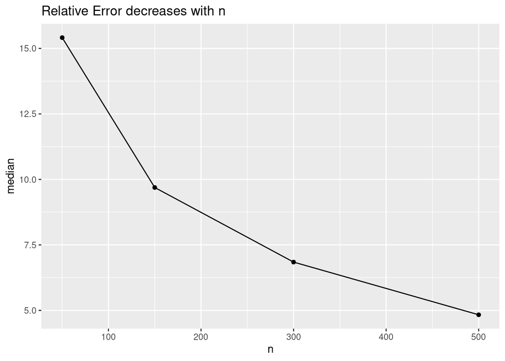

```r
# GOAL: Summarize and plot the relationship between n and relative error.
# TODO: write your own code.

summary_relerr <- sim_relerr %>%
  group_by(n) %>%
  summarise(
    median = median(rel_error_pct),
    p90 = quantile(rel_error_pct, 0.90)
  )

p_relerr <- ggplot(summary_relerr, aes(x = n, y = median)) +
  geom_point() +
  geom_line() +
  labs( title = "Relative Error decreases with n")
p_relerr
```

**Prompt (3–4 sentences):** Describe the pattern. Is improvement from n=25→100 larger than 300→1000?  
Why does accuracy show “diminishing returns” as n increases?

> *There is more improvement in the initial inclination of n densities compared to latter n densities. This accuracy shows diminishing returns because as more replications exist, the sample becomes closer and closer to the median. Just because of the law of randomness, and general data variability, the high-replicated sample data will never 100% match the original. I think of it like getting a 98% on a small assignment in class- you will never be able to get your grade exactly to the perfect 100% it was.*

# Standard error and sampling distributions

For the sample mean, the standard error is approximately:

$$SE(\bar{x}) \approx \frac{\sigma}{\sqrt{n}}$$

where $\sigma$ is population SD.

## 5) Theory vs simulation (partial pipeline)

Compute: - theoretical SE - simulated SD of sample means (over many replications)

```r
set.seed(480)

# TODO: pick a variable and sample size
target_var <- "gpp"
n_samp <- 30
reps <- 500

pop_sd_target <- pop %>% filter(var == target_var) %>% pull(sd)
pop_mean_target <- pop %>% filter(var == target_var) %>% pull(mean)

means <- replicate(
  reps,
  mean(sample(df[[target_var]], size = n_samp, replace = FALSE), na.rm = TRUE)
)

se_theory <- pop_sd_target / sqrt(n_samp)
se_sim    <- sd(means)

tibble(
  target_var = target_var,
  n = n_samp,
  se_theory = se_theory,
  se_simulated = se_sim
)
```

| target_var | n | se_theory | se_simulated |
| --- | --- | --- | --- |
| gpp | 30 | 1.891117 | 1.848058 |

### Plot the sampling distribution (fill-in)

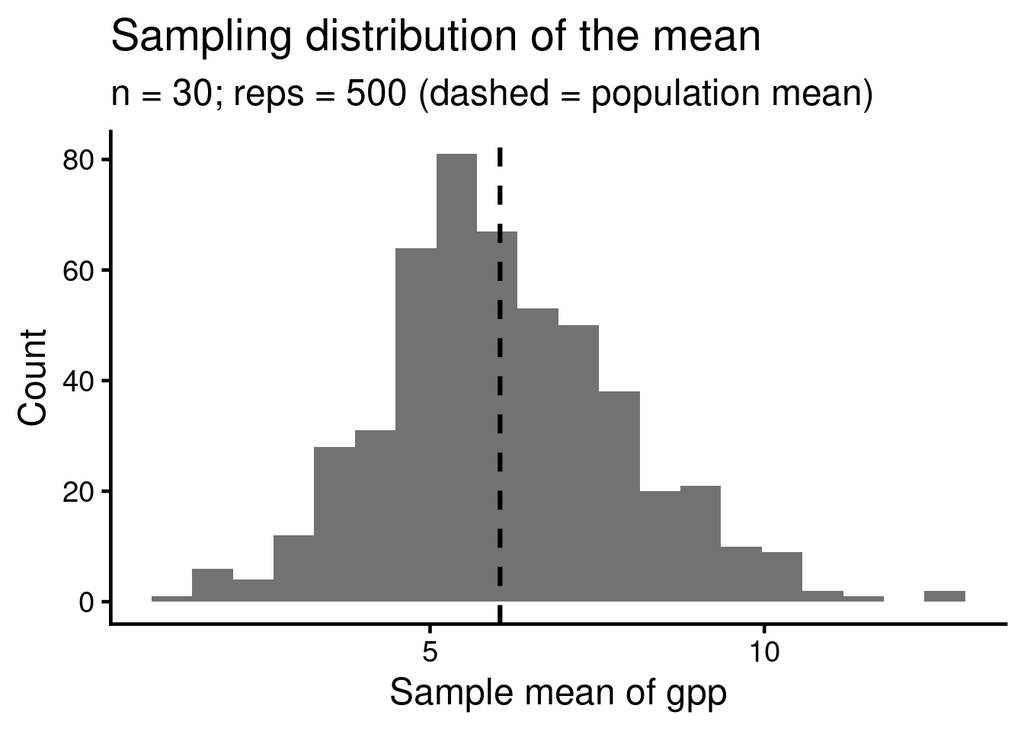

```r
tibble(mean_est = means) %>%
  ggplot(aes(x = mean_est)) +
  geom_histogram(bins = 20, alpha = 0.85) +
  geom_vline(xintercept = pop_mean_target, linetype = "dashed", linewidth = 1.1) +
  theme_classic(base_size = 18) +
  labs(
    x = paste0("Sample mean of ", target_var),
    y = "Count",
    title = "Sampling distribution of the mean",
    subtitle = paste0("n = ", n_samp, "; reps = ", reps, " (dashed = population mean)")
  )
```

**Prompt (3–5 sentences):** How close were `se_theory` and `se_simulated`?  
What changes if you increase `n_samp` vs increase `reps`?

# Bootstrap intuition (one sample, many resamples)

Bootstrap resampling approximates uncertainty **when you only have one sample**.

Key idea: treat your sample as a stand-in for the population and resample **with replacement**.

## 6) Bootstrap distribution of the mean

Write code to:

- take ONE sample of size `n_samp` from `df`
- generate `B` bootstrap resamples (with replacement) from that sample
- compute bootstrap means
- compute bootstrap SD
- plot the bootstrap distribution

```r
set.seed(480)

# TODO: choose settings
target_var <- "gpp"
n_samp <- 30
B <- 1000

# one "field campaign" sample
samp <- tibble(x = sample(df[[target_var]], size = n_samp, replace = FALSE))

# bootstrap sampling of the mean
boot_means <- replicate(
  B,
  mean(sample(samp$x, size = n_samp, replace = TRUE))
)

boot_sd <- sd(boot_means)

tibble(
  sample_mean = mean(samp$x),
  boot_sd = boot_sd
)
```

| sample_mean | boot_sd |
| --- | --- |
| 1.731748 | 1.142151 |

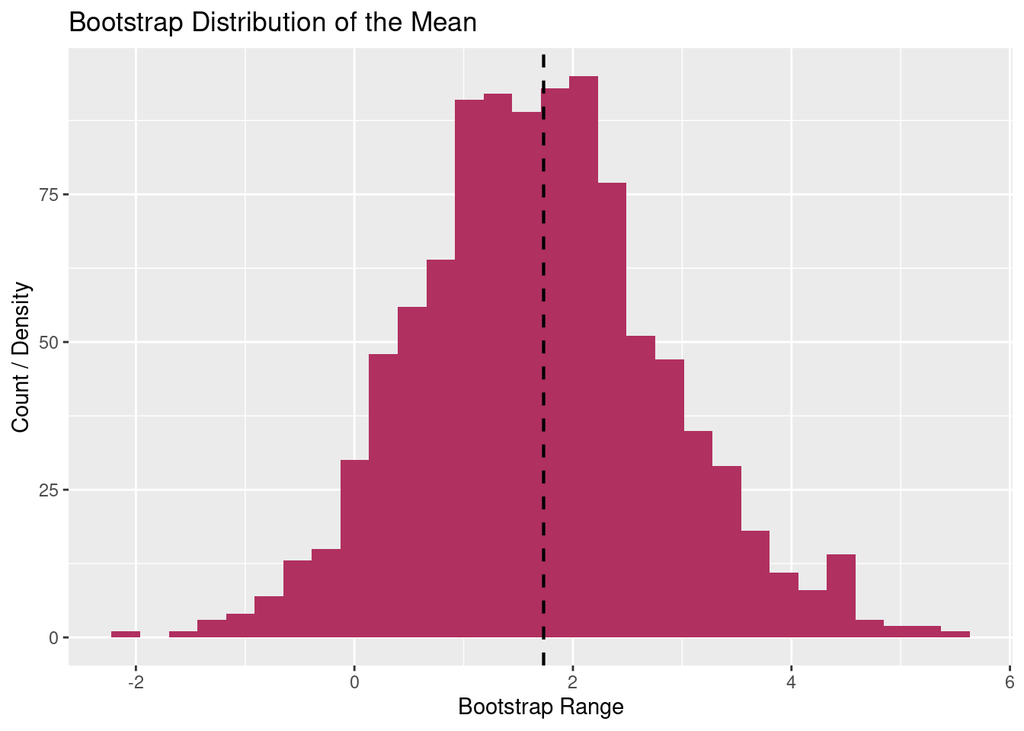

```r
# TODO: plot boot_means and mark the sample mean

tibble(boot_means = boot_means) %>%
  ggplot(aes(x = boot_means)) +
  geom_histogram(bins = 30, fill = "maroon") +
  geom_vline(xintercept = mean(samp$x), linetype = "dashed", linewidth = 0.75) +
  labs(
    title = "Bootstrap Distribution of the Mean",
    x = "Bootstrap Range",
    y = "Count / Density"
  )
```

**Prompt (4–6 sentences):** Compare the bootstrap distribution to the sampling distribution from Part III.  
What is the bootstrap trying to approximate? When is bootstrap especially useful in EAES?

> *The bootstrap is attempting to approximate the population mean using a smaller, replicated sample. This sampling distribution is more bell shaped due to the high number of replications, being B=1000. Bootstrap can be especially useful in EaES when attempting to gauge a population estimate when you don’t have access to enough samples. In this way, you can replicate the samples that you already have to derive something that is closer to the true mean and has a lower standard deviation overall.*

# Part II — Bootstrap under random vs non-random sampling (SWC)

In Part I, you learned that the bootstrap approximates uncertainty **conditional on the sample you observed**.

Now you will test a key warning:

> Bootstrap can quantify *precision* even when the estimate is *biased*.

We will focus on **soil water content (`swc`)**.

- **Population**: all 2023 half-hour records (after removing `NA`)
- **Sample**: one “field campaign” sample of size `n = 200`
- **Bootstrap**: resample *within the sample* (with replacement) many times

## Preparation (recommended)

```r
# GOAL: Ensure df exists (loaded in Part I) and create a clean SWC population vector.

swc_pop <- df$swc
swc_pop <- swc_pop[!is.na(swc_pop)]

pop_mean_swc <- mean(swc_pop)
pop_sd_swc   <- sd(swc_pop)

tibble(
  pop_mean_swc = pop_mean_swc,
  pop_sd_swc   = pop_sd_swc,
  n_pop = length(swc_pop)
)
```

| pop_mean_swc | pop_sd_swc | n_pop |
| --- | --- | --- |
| 35.4762 | 8.158538 | 16913 |

## Exercise 1 — Random sample → bootstrap distribution (baseline)

**Task:** Draw a *simple random sample* of `n = 200` from the SWC population, then bootstrap the mean.

```r
set.seed(480)

n_samp <- 200
B <- 1000

# 1) Draw a random sample (no replacement) from the population vector
swc_samp_random <- sample(swc_pop, size = n_samp, replace = FALSE)

# 2) Bootstrap the mean (resample WITH replacement from the sample)
boot_means_random <- replicate(
  B,
  mean(sample(swc_samp_random, size = n_samp, replace = TRUE))
)

# 3) Summarize
tibble(
  pop_mean = pop_mean_swc,
  sample_mean = mean(swc_samp_random),
  boot_sd = sd(boot_means_random)
)
```

| pop_mean | sample_mean | boot_sd |
| --- | --- | --- |
| 35.4762 | 35.88769 | 0.5575897 |

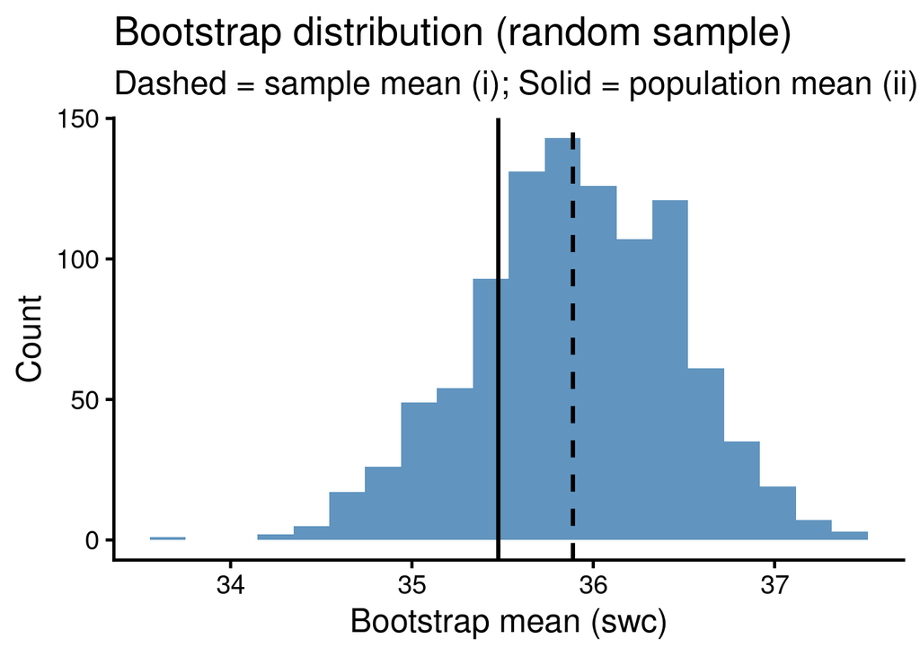

```r
# GOAL: Plot the bootstrap distribution and mark (i) sample mean and (ii) population mean.

tibble(boot_mean = boot_means_random) %>%
  ggplot(aes(x = boot_mean)) +
  geom_histogram(bins = 20, alpha = 0.85, fill = "steelblue") +
  geom_vline(xintercept = mean(swc_samp_random), linetype = "dashed", linewidth = 1.1) +
  geom_vline(xintercept = pop_mean_swc, linetype = "solid", linewidth = 1.1) +
  theme_classic(base_size = 18) +
  labs(
    x = "Bootstrap mean (swc)",
    y = "Count",
    title = "Bootstrap distribution (random sample)",
    subtitle = "Dashed = sample mean (i); Solid = population mean (ii)"
  )
```

**Prompt (3–4 sentences):** Is the bootstrap distribution centered near the population mean?  
What does the bootstrap SD represent here?

> *The bootstrap distribution is centered near the sample mean, not as much the population mean. The bootstrap SD represents the standard deviation away from the core sample mean.The population mean is not centered in the histogram range.*